# Ejemplo - centralidad de eigenvector

Definir una red

```r
library(tidyverse)
library(ggraph)
library(tidygraph)
red_6 <- igraph::graph(c(1,2,1,3,1,4,5,2), directed = FALSE) %>%
  as_tbl_graph() %>% mutate(nombre = 1:5, importancia = 0)
```

Matriz de adyacencia

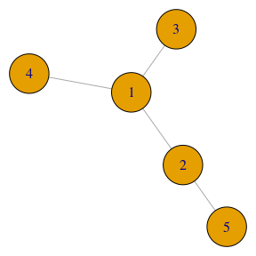

```r
par(mar=c(0,0,0,0))
plot(red_6, vertex.size = 40)
```

```r
A_red <- igraph::get.adjacency(red_6) %>% as.matrix
A_red
```

```
     [,1] [,2] [,3] [,4] [,5]
[1,]    0    1    1    1    0
[2,]    1    0    0    0    1
[3,]    1    0    0    0    0
[4,]    1    0    0    0    0
[5,]    0    1    0    0    0
```

## Calculo de importancias de eigenvector

Tomamos un vector arbitrario primero

```r
# "importancias"
#x_norm <- c(0.307, 0.236, 0.165, 0.165, 0.127)
x_norm <- c(0.3, 0.3, 0.1, 0.1 ,0.2)
sum(x_norm)
```

```
[1] 1
```

Ahora recalculamos a mano importancias según la definición:

**la importancia (normalizada) de un nodo es la suma de las importancias de los nodos adyacentes**:

```r
print("Calculo de suma de importancias")
```

```
[1] "Calculo de suma de importancias"
```

```r
y <- c(0, 0, 0, 0, 0)
y[1] <- x_norm[2] + x_norm[3] + x_norm[4]
y[2] <- x_norm[1] + x_norm[5]
y[3] <- x_norm[1]
y[4] <- x_norm[1]
y[5] <- x_norm[2]
y_norm <- y / sum(y)
y_norm
```

```
[1] 0.2631579 0.2631579 0.1578947 0.1578947 0.1578947
```

Y este vector $y_norm$ no es igual al $x_norm$ inicial. Así que no puede ser las importancias de eigenvector como definimos arriba.

También podemos calcular de forma matricial:

```r
y <- A_red %*% x_norm
y_norm <- as.numeric(y) / sum(y)
y_norm
```

```
[1] 0.2631579 0.2631579 0.1578947 0.1578947 0.1578947
```

que da lo mismo que el cálculo a mano (¿por qué esto es cierto?). Es el mismo cálculo. Conviene **pensarlo y hacerlo en forma matricial**.

Ahora vamos a escoger un vector especial (veremos más adelante cómo encontrarlo)

```r
x_norm_2 <- c(0.307, 0.236, 0.165, 0.165, 0.127)
x_norm_2
```

```
[1] 0.307 0.236 0.165 0.165 0.127
```

```r
y_2 <- A_red %*% x_norm_2
y_norm_2 <- as.numeric(y_2) / sum(y_2)
y_norm_2 %>% round(3)
```

```
[1] 0.306 0.235 0.166 0.166 0.128
```

y nos da prácticamente el mismo vector. Así que este vector x_norm_2 podemos considerarlo como las importancias de eigenvector, según la definición **la importancia (escalada) de un nodo es la suma de las importancias de los nodos adyacentes**

## ¿Cómo encontramos el vector de importancias**

Si calculamos la descomposición espectral de la matriz de adyacencia (encontrar todas las $x$ tales que $A^tx = \lambda x$ para alguna $\lambda$):

```r
descomp <- eigen(t(A_red))
descomp
```

```
eigen() decomposition
$values
[1]  1.8477591  0.7653669  0.0000000 -0.7653669 -1.8477591

$vectors
          [,1]       [,2]          [,3]       [,4]       [,5]
[1,] 0.6532815 -0.2705981  0.000000e+00  0.2705981  0.6532815
[2,] 0.5000000  0.5000000 -8.756053e-17  0.5000000 -0.5000000
[3,] 0.3535534 -0.3535534  7.071068e-01 -0.3535534 -0.3535534
[4,] 0.3535534 -0.3535534 -7.071068e-01 -0.3535534 -0.3535534
[5,] 0.2705981  0.6532815  0.000000e+00 -0.6532815  0.2705981
```

Observamos que si tomamos el vector propio asociado al valor propio más grande,

```r
v <- descomp$vectors[,1]
v_norm <- v / sum(v)
v_norm %>% round(3)
```

```
[1] 0.307 0.235 0.166 0.166 0.127
```

vemos que **recuperamos el vector de importancias**. Asi es como encontramos este vector de importancias. Revisa las notas para ver qué debe cumplir la gráfica para que esto sea cierto.